# Disease Prevalence Modeling: From Binomial to Spatial GP

Development and selection of the disease prevalence modeling workflow

Analysis Summary

2025-12-19

# Introduction

**Note**: This notebook is for **visualization and comparison** of fitted models, not for fitting models. All models should be fitted using the scripts in `code/` (especially `code/2.4_comprehensive_models.R` for the full spatial model suite).

This notebook documents the development of the disease prevalence modeling workflow, starting from basic binomial models and progressing to spatial Gaussian Process models. The primary objective was to evaluate **Niche Centrality Theory** - specifically, whether hosts in optimal niche conditions (characterized by high suitability and central niche/range positions) exhibit distinct disease prevalence patterns.

The model suite (`code/2.4_comprehensive_models.R`) systematically evaluates:

- 12 single-effect spatial models (6 raw variables and 6 within-species decompositions)
- 2 centrality models (isolating within- vs. between-species effects)
- 32 pairwise models (8 targeted variable combinations)
- Non-spatial baselines for reference

The following sections outline the analysis process and results.

# Part 1: Initial Baseline Models - Binomial Likelihood

The investigation started with a standard binomial likelihood approach incorporating basic controls.

## Baseline Models

I tested several baseline options to establish a foundation. Specifically, I tested the following models:

- m0_base: Minimal baseline (binomial)

```
## number_positive | trials(number_tested) ~ 1 + assay_group + (1 | host_species)
```

- m0_base_bb: Minimal baseline (beta-binomial)

```
## number_positive | trials(number_tested) ~ 1 + assay_group + (1 | host_species)
```

- m0_controls: With broad biology controls (binomial)

```
## number_positive | trials(number_tested) ~ 1 + assay_group + host_family + pathogen_family + (1 | host_species)
```

- m0_beta_binom: With controls (beta-binomial)

```
## number_positive | trials(number_tested) ~ 1 + assay_group + host_family + pathogen_family + (1 | host_species)
```

## Diagnostic Evaluation: Posterior Predictive Checks

Posterior predictive checks (PPCs) were used to evaluate model fit and identify areas of systematic misspecification.

### Overall Prevalence Distribution

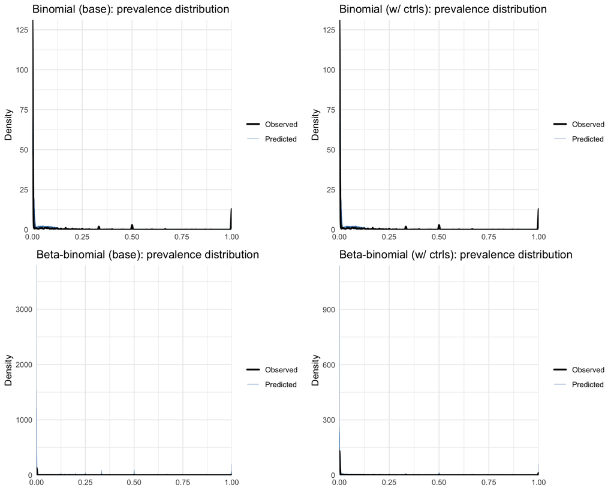

### Inspection of Specific Prevalence Ranges

Model performance was examined across different regions of the prevalence distribution:

#### Low Prevalence Region (0 to 0.025)

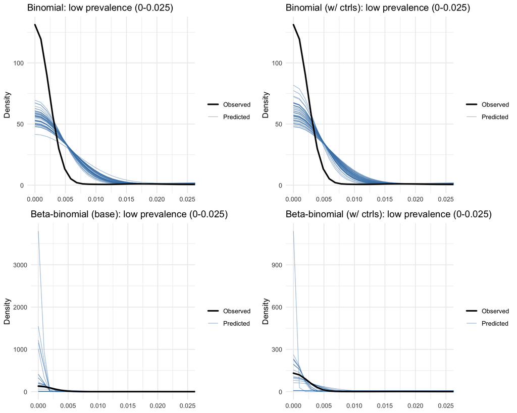

**Observation**: The binomial model failed to capture the high frequency of observations in the low-prevalence range. The beta-binomial models provided a more accurate representation of this feature.

#### High Prevalence Region (0.999 to 1.0)

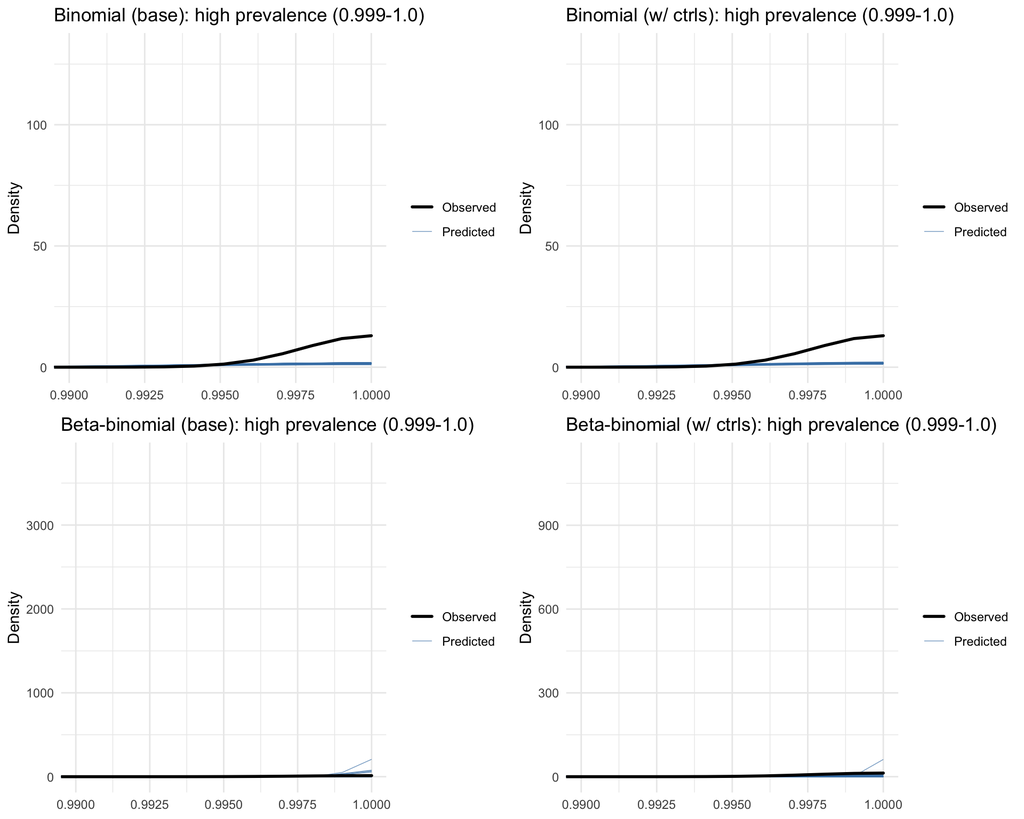

#### Middle Range (0.4975 to 0.5025)

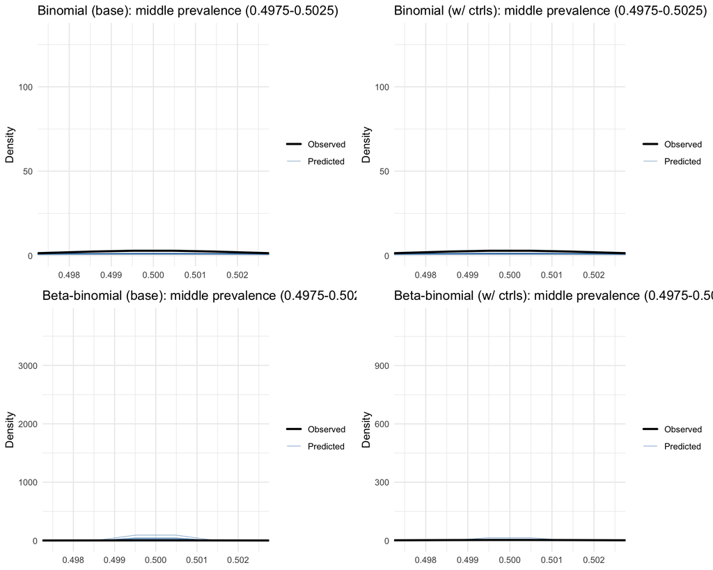

### Test Statistics: Mean and Zero-Mass

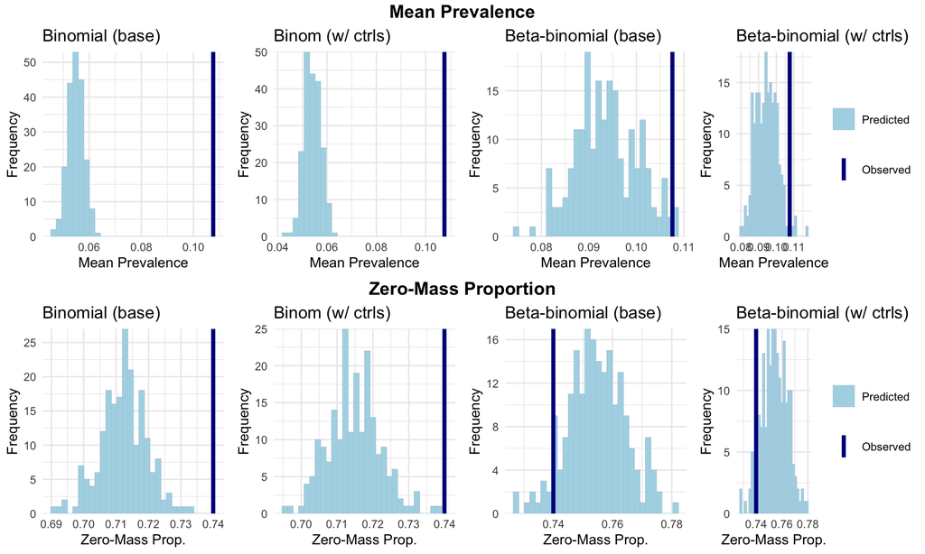

### LOO-PIT Calibration

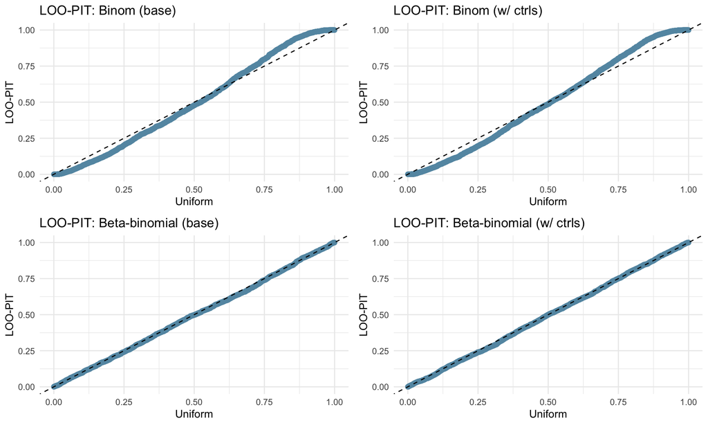

**Takeaway**: The binomial model appears misspecified. A beta-binomial approach is required to account for overdispersion.

# Part 2: Accounting for Overdispersion - Beta-Binomial Models

Posterior predictive checks indicate that the beta-binomial model provides a better fit than the standard binomial model. Quantitative comparison using PSIS-LOO confirms this improvement:

```
##               elpd_diff se_diff
## m0_base_bb        0.0       0.0
## m0_beta_binom    -0.6       1.6
## m0_base       -2191.1     339.4
## m0_controls   -2192.4     337.4
```

ELPD stands for Expected Log Predictive Density, and is a measure of the predictive performance of a model here. The beta-binomial model improves ELPD by more than 2000 points, indicating that the standard binomial likelihood is misspecified for these data.

## Rationale for Beta-Binomial

The data shows strong **overdispersion** - variability exceeding that predicted by a binomial distribution. The beta-binomial distribution accounts for this by allowing the success probability to vary across observations according to a beta distribution, which is consistent with the hierarchical nature of prevalence data across diverse host-pathogen contexts.

# Part 3: Evaluation of Niche Predictors

Following the adoption of the beta-binomial likelihood, several niche predictors were evaluated:

Fitted the following models to exlore individual niche predictors:

```
## number_positive | trials(number_tested) ~ 1 + prob_occur_orderNorm + assay_group + (1 | host_species)
##  number_positive | trials(number_tested) ~ 1 + Suitability_orderNorm + assay_group + (1 | host_species)
##  number_positive | trials(number_tested) ~ 1 + Marginality_orderNorm + assay_group + (1 | host_species)
##  number_positive | trials(number_tested) ~ 1 + Specificity_orderNorm + assay_group + (1 | host_species)
##  number_positive | trials(number_tested) ~ 1 + Centroid_d_orderNorm + assay_group + (1 | host_species)
##  number_positive | trials(number_tested) ~ 1 + Boundary_d_orderNorm + assay_group + (1 | host_species)
```

Compared the models to the baseline model using PSIS-LOO:

```
##            elpd_diff se_diff
## m1prob_v2   0.0       0.0
## m1marg_v2  -0.3       2.5
## m0_base_bb -1.7       2.3
## m1spec_v2  -2.0       2.7
## m1centr_v2 -2.2       2.9
## m1suit_v2  -3.0       2.6
## m1bound_v2 -3.2       2.5
```

Initial comparisons showed that the niche predictors had similar predictive performance, with differences typically smaller than one standard error. This lack of clear separation suggested that additional structural components, such as spatial autocorrelation, might be necessary to distinguish between competing hypotheses. Further exploration of these models (not shown here) by using pairwise comparisons showed that the models were effectively tied, and other components of the model needed to be adjusted to identify differences.

# Part 4: Accounting for Spatial Autocorrelation

**Spatial autocorrelation** may be incorporated into the model structure, as prevalence observations are likely to be clustered geographically.

## Integration of Spatial Gaussian Processes

A Gaussian Process (GP) term was added to the model using standardized longitude and latitude coordinates:

```r
# Add standardized coordinates
scaled_covars <- scaled_covars |>
  mutate(
    lon_z = as.numeric(scale(longitude)),
    lat_z = as.numeric(scale(latitude))
  )
```

The spatial baseline model formulation:

```
## number_positive | trials(number_tested) ~ 1 + assay_group + (1 | host_species) + gp(lon_z, lat_z, k = 20)
```

Now we are comparing these 2 models:

```
## Spatial model:
##  number_positive | trials(number_tested) ~ 1 + assay_group + (1 | host_species) + gp(lon_z, lat_z, k = 20)
##
##  Non-spatial model:
##  number_positive | trials(number_tested) ~ 1 + assay_group + (1 | host_species)
```

And here are the LOO results of the comparison:

```
##            elpd_diff se_diff
## m0_spatial   0.0       0.0
## m0_base_bb -31.6       7.9
```

Incorporating spatial structure results in an ELPD improvement of ~30-40 points, demonstrating the importance of accounting for spatial clustering in prevalence data.

# Part 5: Within-Species Decomposition

To evaluate the Niche Centrality Hypothesis, niche predictors were decomposed into two components to isolate within-species variation:

- **Between-species component**: Representing species-level average niche positions.
- **Within-species component**: Representing site-level deviations from the species mean.

This decomposition can help determine if sites that are central relative to a species’ specific niche exhibit different prevalence patterns, independent of broader species-level differences.

## Centrality Score Decomposition

A centrality score was calculated as `Suitability - Marginality` (where higher values indicate more central niche positions) and decomposed as follows (TBC):

```r
# Show the decomposition (already done in data prep)
scaled_covars <- scaled_covars |>
  mutate(
    centrality_score_raw = Suitability_orderNorm - Marginality_orderNorm,
    Suitability_between_raw = ave(Suitability_orderNorm, host_species, FUN = mean),
    Marginality_between_raw = ave(Marginality_orderNorm, host_species, FUN = mean),
    centrality_between_raw = Suitability_between_raw - Marginality_between_raw,
    centrality_within_raw = centrality_score_raw - centrality_between_raw,
    centrality_within_z = as.numeric(scale(centrality_within_raw)),
    centrality_between_z = as.numeric(scale(centrality_between_raw))
  )
```

## Targeted Approach: Within-Species Centrality with Spatial Control

The model with within-species centrality was fit with a spatial control term to account for spatial autocorrelation. The model formula was:

```
## number_positive | trials(number_tested) ~ 1 + centrality_within_z + assay_group + (1 | host_species) + gp(lon_z, lat_z, k = 20)
```

This model was then compared to the spatial baseline model using PSIS-LOO:

```
##                             elpd_diff se_diff
## m1centrality_within_spatial  0.0       0.0
## m0_spatial                  -7.2       3.6
```

### Parameter Estimates

The parameter estimates for the within-species centrality model were:

```
##                     Estimate Est.Error  Q2.5 Q97.5
## centrality_within_z    0.149     0.044 0.064 0.244
```

**Interpretation**:

- The estimate for within-species centrality (β = 0.15, 95% CrI [0.07, 0.24]) is positive on the log-odds scale.
- This corresponds to an **Odds Ratio of ~1.16** per one standard deviation increase in within-species centrality.
- Sites that are more central relative to a species’ average niche position are associated with systematically higher prevalence.

This relationship remains consistent when controlling for:

- Spatial autocorrelation (GP term)
- Species-level heterogeneity (random effects)
- Methodological variation (fixed effect for assay group)
- Overdispersion (beta-binomial likelihood)

# Part 6: Comprehensive Model Comparison

The following sections present a comprehensive evaluation of the models developed.

## Model Suite Overview

The comprehensive suite evaluated:

- **Spatial baseline** (`m0_spatial`)
- **12 single-effect spatial models** (6 raw variables and 6 within-species decompositions)
- **2 centrality models** (isolating within- vs. between-species effects)
- **32 pairwise models** (8 targeted variable combinations)
- **Non-spatial models** from previous analysis steps

## Prior Specifications

Weakly informative priors were used to provide regularisation and ensure computational stability:

- **Intercept**: `Normal(0, 1.5)` — broad prior on the log-odds scale.
- **Regression Coefficients (b)**: `Normal(0, 1)` — regularising niche and control effects.
- **Random Effect SDs (sd)**: `Exponential(1)` — penalising overly complex hierarchies.
- **Overdispersion (phi)**: `Exponential(1)` — (Beta-Binomial only) allowing for site-level clustering.
- **GP Hyperparameters**: (Spatial models only)
  - **SD (sdgp)**: `Exponential(1)`
  - **Length-scale (lscale)**: `Exponential(1)` — broad scale for spatial processes.

**Model notation guide**:

- **[raw]**: Predictors used as original site-level values.
- **[within]**: Within-species decomposed component (site-level deviation from the species mean).
- **(+)**: Additive model structure (sum of effects).
- **(*)**: Interaction model (includes main effects and their interaction).

All Models by ELPD

| Model | Family | Type | ΔELPD | SE |
| --- | --- | --- | --- | --- |
| Centrality (within) | Beta-Binomial | Spatial | 0.00 | 0.00 |
| Suit Marg [raw] (+) | Beta-Binomial | Spatial | -0.05 | 0.56 |
| Suit Marg [within] (+) | Beta-Binomial | Spatial | -0.77 | 0.77 |
| Suit Marg [raw] (*) | Beta-Binomial | Spatial | -0.79 | 1.19 |
| Suit Marg [within] (*) | Beta-Binomial | Spatial | -1.80 | 1.09 |
| BoundDist Marg [raw] (+) | Beta-Binomial | Spatial | -2.52 | 3.22 |
| Suitability (within) | Beta-Binomial | Spatial | -2.67 | 2.61 |
| Suitability (raw) | Beta-Binomial | Spatial | -2.81 | 2.58 |
| BoundDist Marg [within] (*) | Beta-Binomial | Spatial | -3.06 | 3.79 |
| Suit Spec [raw] (*) | Beta-Binomial | Spatial | -3.08 | 2.54 |
| Marginality (within) | Beta-Binomial | Spatial | -3.15 | 2.87 |
| CentrDist Suit [raw] (+) | Beta-Binomial | Spatial | -3.18 | 2.52 |
| BoundDist Marg [within] (+) | Beta-Binomial | Spatial | -3.42 | 3.16 |
| CentrDist Suit [within] (*) | Beta-Binomial | Spatial | -3.67 | 2.75 |
| CentrDist Suit [raw] (*) | Beta-Binomial | Spatial | -3.76 | 2.99 |
| Suit Spec [raw] (+) | Beta-Binomial | Spatial | -3.83 | 2.61 |
| Suit Spec [within] (+) | Beta-Binomial | Spatial | -4.03 | 2.65 |
| Suit Spec [within] (*) | Beta-Binomial | Spatial | -4.32 | 2.70 |
| Prob Marg [within] (*) | Beta-Binomial | Spatial | -4.48 | 3.30 |
| Marg Spec [within] (+) | Beta-Binomial | Spatial | -4.50 | 2.93 |
| BoundDist Marg [raw] (*) | Beta-Binomial | Spatial | -4.53 | 3.40 |
| CentrDist Suit [within] (+) | Beta-Binomial | Spatial | -4.62 | 2.64 |
| Boundary dist (within) | Beta-Binomial | Spatial | -4.64 | 3.86 |
| Marginality (raw) | Beta-Binomial | Spatial | -4.88 | 2.87 |
| Boundary dist (raw) | Beta-Binomial | Spatial | -5.01 | 3.92 |
| Prob Marg [within] (+) | Beta-Binomial | Spatial | -5.29 | 2.85 |
| Marg Spec [raw] (+) | Beta-Binomial | Spatial | -5.39 | 2.89 |
| Prob Marg [raw] (+) | Beta-Binomial | Spatial | -5.48 | 2.86 |
| Prob Marg [raw] (*) | Beta-Binomial | Spatial | -5.86 | 2.88 |
| Centrality (between) | Beta-Binomial | Spatial | -5.92 | 3.72 |
| CentrDist BoundDist [raw] (*) | Beta-Binomial | Spatial | -6.00 | 4.16 |
| Marg Spec [within] (*) | Beta-Binomial | Spatial | -6.19 | 2.92 |
| CentrDist BoundDist [raw] (+) | Beta-Binomial | Spatial | -6.20 | 4.00 |
| CentrDist BoundDist [within] (+) | Beta-Binomial | Spatial | -6.26 | 3.88 |
| Specificity (within) | Beta-Binomial | Spatial | -6.67 | 3.67 |
| Prob occur (within) | Beta-Binomial | Spatial | -6.68 | 3.86 |
| Centroid dist (raw) | Beta-Binomial | Spatial | -6.73 | 3.63 |
| Specificity (raw) | Beta-Binomial | Spatial | -6.81 | 3.65 |
| Centroid dist (within) | Beta-Binomial | Spatial | -6.94 | 3.65 |
| Marg Spec [raw] (*) | Beta-Binomial | Spatial | -7.13 | 3.04 |
| Spatial baseline | Beta-Binomial | Spatial | -7.16 | 3.63 |
| Prob occur (raw) | Beta-Binomial | Spatial | -7.78 | 3.79 |
| CentrDist BoundDist [within] (*) | Beta-Binomial | Spatial | -7.85 | 3.92 |
| Prob Spec [within] (+) | Beta-Binomial | Spatial | -8.50 | 3.93 |
| Prob Spec [raw] (*) | Beta-Binomial | Spatial | -8.98 | 3.89 |
| Prob Spec [raw] (+) | Beta-Binomial | Spatial | -9.08 | 3.86 |
| Prob Spec [within] (*) | Beta-Binomial | Spatial | -9.15 | 4.00 |
| Prob occur | Beta-Binomial | Non-spatial | -37.01 | 8.72 |
| Marginality | Beta-Binomial | Non-spatial | -37.34 | 8.44 |
| Prob + Marg | Beta-Binomial | Non-spatial | -37.44 | 8.47 |
| Prob * Marg | Beta-Binomial | Non-spatial | -37.49 | 8.39 |
| Marginality | Beta-Binomial | Non-spatial | -37.51 | 8.41 |
| Prob occur | Beta-Binomial | Non-spatial | -37.58 | 8.70 |
| Suit + Marg | Beta-Binomial | Non-spatial | -38.30 | 8.47 |
| Beta-binomial baseline | Beta-Binomial | Non-spatial | -38.72 | 8.89 |
| Centrality | Beta-Binomial | Non-spatial | -39.01 | 8.85 |
| Specificity | Beta-Binomial | Non-spatial | -39.05 | 8.91 |
| Suit * Marg | Beta-Binomial | Non-spatial | -39.17 | 8.58 |
| Centrality | Beta-Binomial | Non-spatial | -39.19 | 8.89 |
| Beta-binom + controls | Beta-Binomial | Non-spatial | -39.35 | 8.85 |
| Specificity | Beta-Binomial | Non-spatial | -39.48 | 8.87 |
| Suitability | Beta-Binomial | Non-spatial | -40.01 | 8.89 |
| Suitability | Beta-Binomial | Non-spatial | -40.02 | 8.93 |
| Boundary dist | Beta-Binomial | Non-spatial | -40.25 | 9.00 |
| Boundary dist | Beta-Binomial | Non-spatial | -40.27 | 8.94 |
| Binomial baseline | Binomial | Non-spatial | -2229.81 | 339.72 |
| Binomial + controls | Binomial | Non-spatial | -2231.10 | 337.67 |

## Summary of Results

Top 15 Models by ELPD

| Model | Family | Type | ΔELPD | SE |
| --- | --- | --- | --- | --- |
| Centrality (within) | Beta-Binomial | Spatial | 0.00 | 0.00 |
| Suit Marg [raw] (+) | Beta-Binomial | Spatial | -0.05 | 0.56 |
| Suit Marg [within] (+) | Beta-Binomial | Spatial | -0.77 | 0.77 |
| Suit Marg [raw] (*) | Beta-Binomial | Spatial | -0.79 | 1.19 |
| Suit Marg [within] (*) | Beta-Binomial | Spatial | -1.81 | 1.09 |
| BoundDist Marg [raw] (+) | Beta-Binomial | Spatial | -2.52 | 3.22 |
| Suitability (within) | Beta-Binomial | Spatial | -2.67 | 2.61 |
| Suitability (raw) | Beta-Binomial | Spatial | -2.81 | 2.58 |
| BoundDist Marg [within] (*) | Beta-Binomial | Spatial | -3.06 | 3.79 |
| Suit Spec [raw] (*) | Beta-Binomial | Spatial | -3.08 | 2.54 |
| Marginality (within) | Beta-Binomial | Spatial | -3.15 | 2.86 |
| CentrDist Suit [raw] (+) | Beta-Binomial | Spatial | -3.18 | 2.52 |
| BoundDist Marg [within] (+) | Beta-Binomial | Spatial | -3.42 | 3.16 |
| CentrDist Suit [within] (*) | Beta-Binomial | Spatial | -3.67 | 2.75 |
| CentrDist Suit [raw] (*) | Beta-Binomial | Spatial | -3.76 | 2.99 |

# Part 7: Visualizing Top Models

The following sections provide visualizations of the top-performing models:

## Test Statistics

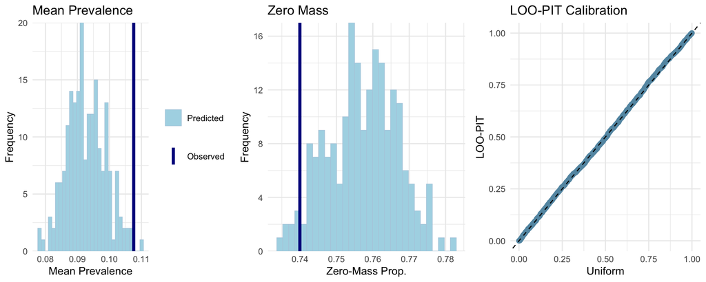

## Parameter Estimation

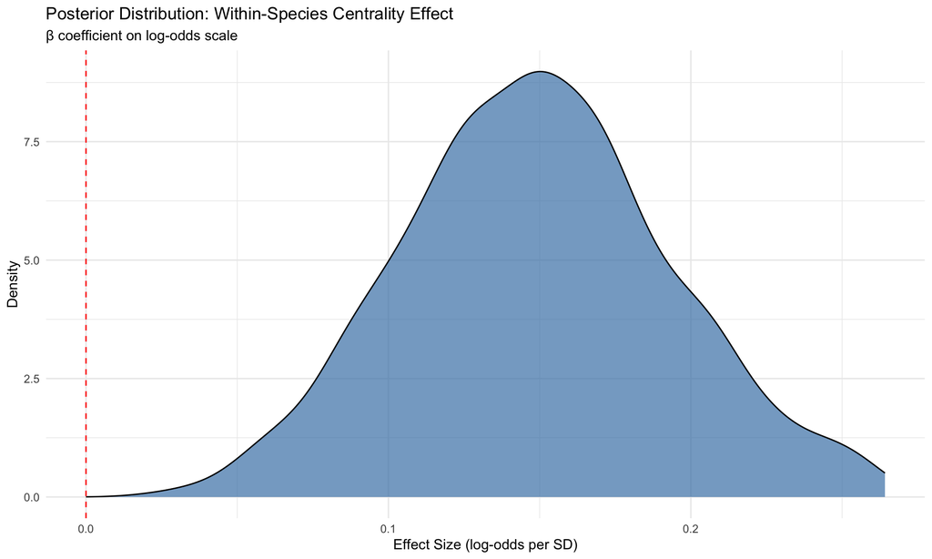

## Model Comparison Summary

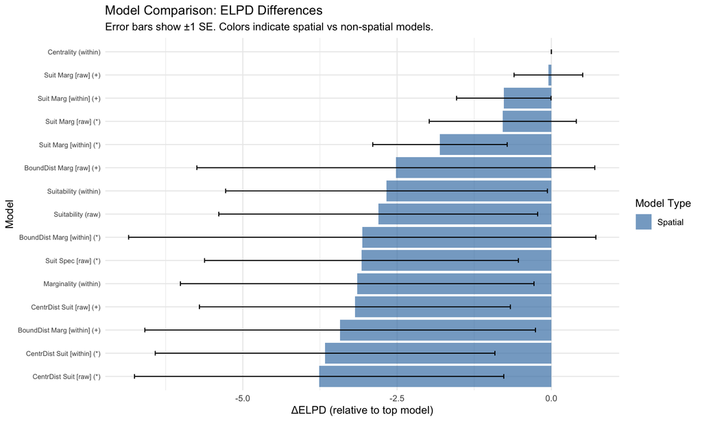

# Part 8: Detailed Exploration of Production Models

The top-performing models identified in the screening phase were refitted using production-level settings (2000 iterations, 4 chains, and increased `adapt_delta = 0.99`) to ensure robust posterior estimation and convergence.

## Production Model Parameters

The table below summarizes the fixed-effect estimates and Bayes $R^2$ for the production model suite. All models listed here use the **Beta-Binomial** likelihood and include **Spatial GP** controls.

Production Model Fixed Effects (Niche Predictors)

| Model | Parameter | Estimate (logit) | 95% CrI | Bayes R2 |
| --- | --- | --- | --- | --- |
| Centrality (within) | centrality_within_z | 0.151 | [0.065, 0.235] | 0.606 |
| Suit + Marg [raw] (+) | Suitability_orderNorm | 0.157 | [0.05, 0.268] | 0.603 |
|  | Marginality_orderNorm | -0.179 | [-0.305, -0.05] | 0.603 |
| Suit + Marg [within] (+) | Suitability_within_z | 0.099 | [0.018, 0.179] | 0.603 |
|  | Marginality_within_z | -0.142 | [-0.237, -0.049] | 0.603 |
| Suit * Marg [raw] (*) | Suitability_orderNorm | 0.169 | [0.059, 0.276] | 0.602 |
|  | Marginality_orderNorm | -0.203 | [-0.331, -0.068] | 0.602 |
|  | Suitability_orderNorm:Marginality_orderNorm | -0.067 | [-0.177, 0.042] | 0.602 |
| Suit * Marg [within] (*) | Suitability_within_z | 0.098 | [0.02, 0.178] | 0.600 |
|  | Marginality_within_z | -0.124 | [-0.232, -0.017] | 0.600 |
|  | Suitability_within_z:Marginality_within_z | 0.025 | [-0.056, 0.105] | 0.600 |

## Visual Comparison of Production Models

The following figures provide a visual summary of the production results, including coefficient comparisons, the relationship between niche variables and predicted prevalence, and host species random effects.

### Fixed Effects Comparison

This plot compares the effect sizes of niche predictors across the top 5 models. Consistent positive effects of suitability/centrality and negative effects of marginality are observed.

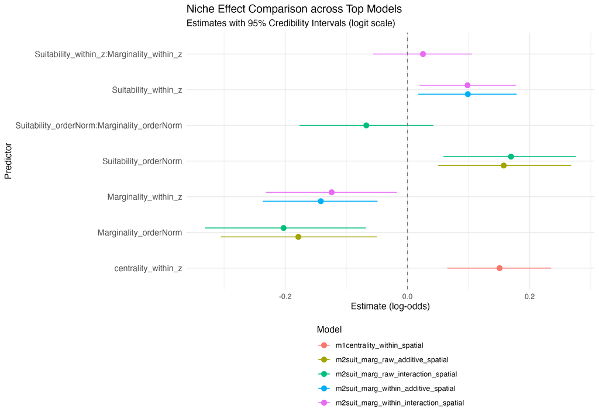

### Predicted Prevalence Curves

Overlaid prediction curves showing how disease prevalence changes across the range of Suitability or Centrality (standardized units). Shaded regions represent 95% credibility intervals.

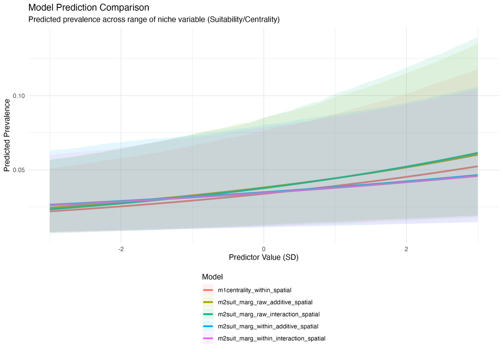

### Host Species Heterogeneity

Random intercepts (on the log-odds scale) for host species from the best-performing model (`m1centrality_within_spatial`). This highlights the substantial variation in baseline prevalence across the host community.

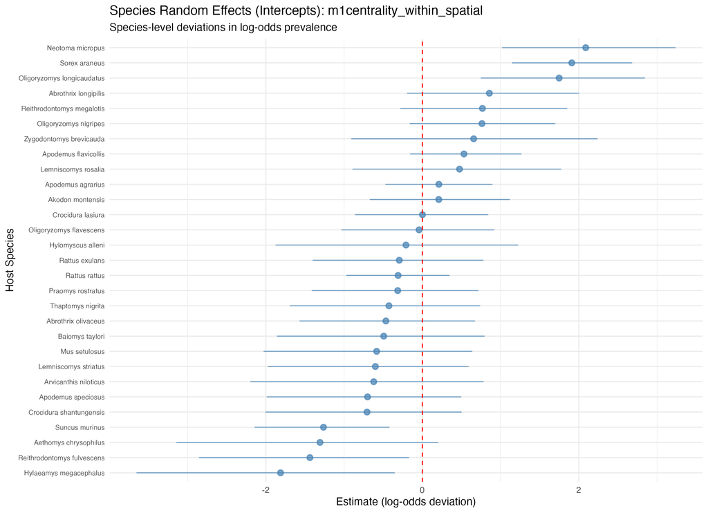

# Part 9: Key Conclusions and Next Steps

## Key Conclusions

1. **Likelihood Selection**: A beta-binomial likelihood is necessary to account for strong overdispersion in prevalence data.
2. **Spatial Structure**: Incorporating spatial structure via Gaussian Processes is essential for capturing geographical clustering and ensuring accurate inference.
3. **Variable Decomposition**: Isolating within-species variation is critical for evaluating niche-based hypotheses, as centrality effects are most evident at the site level within each species.
4. **Niche Centrality Support**: The analysis provides strong evidence for the Niche Centrality Hypothesis; sites that are central relative to a species’ niche are associated with higher disease prevalence. This is confirmed across the production model suite, with **within-species centrality** (`Suitability - Marginality`) emerging as a robust predictor with a positive effect (β ≈ 0.15 on the log-odds scale).
5. **Multi-Predictor Robustness**: Additive models combining Suitability and Marginality show that both components contribute independently to prevalence patterns, with higher habitat suitability and lower niche marginality both associated with increased pathogen prevalence.

## Model Architecture (best so far)

The validated model structure used for analysis:

```
number_positive | trials(number_tested) ~
  1 + centrality_within_z + assay_group +
  (1 | host_species) + gp(lon_z, lat_z, k = 20)
```

**Family**: `beta_binomial(link = "logit")`